## Modifying Notebook display

```python
from IPython.display import display, HTML

display(HTML(data="""
<style>
    .container#notebook-container    { width: 95%;}
    div#menubar-container     { width: 95%; }
    div#maintoolbar-container { width: 95%; }
</style>
<script>
    document.getElementById("notebook-container").style.margin = "auto";
</script>
"""))
```

## For running the notebook as Google Colab Instance

# mounting the google drive for accessing other necessary files

from google.colab import drive drive.mount('/content/gdrive')

# Checking the available files in the "Colab Notebooks" folder of the google drive

!ls /content/gdrive/My\ Drive/Colab\ Notebooks

import sys

# changing the current working directory to "Colab Notebooks" folder in the google drive

sys.path.append('/content/gdrive/My Drive/Colab Notebooks')

## For running the notebook as Kaggle Kernel

change directory to the dataset where our custom scripts are uploaded

> `os.chdir("/kaggle/input/handwritten-digit-recognition")`

*handwritten-digit-recognition* is simply a folder name. It can vary based on the dataset you create in kaggle while uploading the python scripts.

load custom module or files or dataset

> `from dataset import load_dataset, train_dev_split, prep_dataset`  
> `from dataset import visualize_data_distribution, visualize_dataset`

reset our working directory

> `os.chdir("/kaggle/working/")`

**NOTE:** The *input directory* is Read-Only. So, we must switch back to the *working directory* for performing any other operation that requires write access. Make sure this note book runs as a part of the dataset you create as said above because all the custom modules are uploaded there.

## Importing Dependencies

```python
# Python Standard Libraries for importing data from binary file
import time    #for calculating time

#core packages
import numpy as np
import matplotlib.pyplot as plt

# os.chdir("/kaggle/input/handwritten-digit-recognition")


#custom module
from  dataset import load_dataset, train_dev_split, prep_dataset
from dataset import visualize_data_distribution, visualize_dataset

from ffnn import init_layers, init_hyperParams
from ffnn import train, evaluate

from ModelUtils import  convert_time
from ModelUtils import save_model, load_model


# # reset our working directory
# os.chdir("/kaggle/working/")


np.random.seed(1)
%matplotlib inline
```

```python
dataset_size_in_per = 50

train_x_orig, train_y_orig, test_x_orig, test_y_orig = load_dataset(dataset = "mnist", size_in_per = dataset_size_in_per)

print("Sample Size : %d%%\n"%(dataset_size_in_per))
print("Data\t\t\t","Datatype\t\t","Dataset Size")
print("=================================================================")
print("Training Set Images:\t" + str(type(train_x_orig))+"\t",str(train_x_orig.shape))
print("Training Set Labels:\t" + str(type(train_y_orig))+"\t",str(train_y_orig.shape))
print("Test Set Images:\t" + str(type(test_x_orig))+"\t",str(test_x_orig.shape))
print("Test Set Labels:\t" + str(type(test_y_orig))+"\t",str(test_y_orig.shape))
print("=================================================================")
```

```
Sample Size : 50%

Data			 Datatype		 Dataset Size
=================================================================
Training Set Images:	<class 'numpy.ndarray'>	 (30000, 28, 28)
Training Set Labels:	<class 'numpy.ndarray'>	 (30000, 1)
Test Set Images:	<class 'numpy.ndarray'>	 (5000, 28, 28)
Test Set Labels:	<class 'numpy.ndarray'>	 (5000, 1)
=================================================================
```

```python
train_x_split, train_y_split, dev_x_split, dev_y_split = train_dev_split(train_x_orig, train_y_orig)

print("Data\t\t\t\t","Datatype\t\t","Shape")
print("========================================================================")
print("Training Set Images:\t\t" + str(type(train_x_split))+"\t",str(train_x_split.shape))
print("Training Set Labels:\t\t" + str(type(train_y_split))+"\t",str(train_y_split.shape))
print("Development Set Images:\t\t" + str(type(dev_x_split))+"\t",str(dev_x_split.shape))
print("Development Set Labels:\t\t" + str(type(dev_y_split))+"\t",str(dev_y_split.shape))
print("========================================================================")
```

```
Data				 Datatype		 Shape
========================================================================
Training Set Images:		<class 'numpy.ndarray'>	 (25000, 28, 28)
Training Set Labels:		<class 'numpy.ndarray'>	 (25000, 1)
Development Set Images:		<class 'numpy.ndarray'>	 (5000, 28, 28)
Development Set Labels:		<class 'numpy.ndarray'>	 (5000, 1)
========================================================================
```

```python
train_x_norm, train_y_encoded = prep_dataset(train_x_split, train_y_split, num_class = 10)
dev_x_norm, dev_y_encoded= prep_dataset(dev_x_split, dev_y_split, num_class = 10)
test_x_norm, test_y_encoded = prep_dataset(test_x_orig, test_y_orig, num_class = 10)

print("Data\t\t\t","Before Processing\t","After Processing")
print("=================================================================")
print("Training Set Images:\t" + str(train_x_split.shape)+"\t\t"+ str(train_x_norm.shape))
print("Training Set Labels:\t" + str(train_y_split.shape)+"\t\t"+ str(train_y_encoded.shape))
print("Dev Set Images:\t\t" + str(dev_x_split.shape)+"\t\t"+ str(dev_x_norm.shape))
print("Dev Set Labels:\t\t" + str(dev_y_split.shape)+"\t\t"+ str(dev_y_encoded.shape))
print("Test Set Images:\t" + str(test_x_orig.shape)+"\t\t"+ str(test_x_norm.shape))
print("Test Set Labels:\t" + str(test_y_orig.shape)+"\t\t"+ str(test_y_encoded.shape))
print("=================================================================")
```

```
Data			 Before Processing	 After Processing
=================================================================
Training Set Images:	(25000, 28, 28)		(784, 25000)
Training Set Labels:	(25000, 1)		(10, 25000)
Dev Set Images:		(5000, 28, 28)		(784, 5000)
Dev Set Labels:		(5000, 1)		(10, 5000)
Test Set Images:	(5000, 28, 28)		(784, 5000)
Test Set Labels:	(5000, 1)		(10, 5000)
=================================================================
```

## Grid Search

### Defining the search parameters

```python
architecture = [[2900],
                [3700],
                [800],
                [3100],
                [1200],
                [2100],
                [800,800],
                [1500,1000,500],
                [1024,1024,1024,1024],
                [2500,2000,1500,1000,500]]

keep_probs = [0.4, 0.5, 0.6, 0.7, 0.8, 0.9]

# inits = ["random", "he"]
# optimizers = ["bgd","mgd", "adam"]
# regularizers = ["l2", "dropout"]
# hidden_units = [512, 1024, 1500, 2048, 2500, 4096]
# hidden_layers = [1,2,3,4,5]

# constants:
#     learning rate: 0.01
#     minibatch size: 128
#     epoch: 10
```

```python
def grid_search(param1,param2, metric = "acc"):

    score = np.zeros((len(param1),len(param2)))

    toc = time.time()

    for ind1, i in enumerate(param1):
        print("\nNo. of Hidden Units: " + str(i))
        print("==========================================================================================================")

        for ind2, j in enumerate(param2):
            kp = [j for x in range(len(i))]
#             hd = [i for x in range(j)]
            print("\n Keep_probs: " + str(kp))
            print("-------------------------------")

            layers_dim = init_layers(784, 10, hidden_layers = i)

            hyperParams = init_hyperParams(alpha = 0.01, num_epoch = 5, minibatch_size = 128, keep_probs = kp)
            history = train(train_x_norm, train_y_encoded, dev_x_norm, dev_y_encoded,layers_dim, hyperParams, initialization = "he", optimizer = 'adam',regularizer = "dropout", verbose = 3)

            if metric == "acc":
                val_acc = history["val_accuracy"][-1]
                score[ind1,ind2] = val_acc
            elif metric == "f1-score":
                pass
            else:
                raise ValueError("Metric must be 'acc' or 'f1-score'")

    tic = time.time() # for calculating entire search time
    hrs, mins, secs , ms = convert_time((tic - toc)*1000)

    print("\n\n*************************** Total Training Time = %dhr %dmins %dsecs %.2fms ***************************"%(hrs, mins, secs, ms))

    return score
```

```python
score = grid_search(architecture,keep_probs, metric = "acc")
```

```
No. of Hidden Units: [2900]
==========================================================================================================

 Keep_probs: [0.4]
-------------------------------
Training The Model...


Total Training Time = 0hr 1mins 6secs 340.01ms

 Keep_probs: [0.5]
-------------------------------
Training The Model...


Total Training Time = 0hr 1mins 16secs 514.90ms

 Keep_probs: [0.6]
-------------------------------
Training The Model...


Total Training Time = 0hr 1mins 17secs 684.89ms

 Keep_probs: [0.7]
-------------------------------
Training The Model...


Total Training Time = 0hr 1mins 21secs 217.41ms

 Keep_probs: [0.8]
-------------------------------
Training The Model...


Total Training Time = 0hr 1mins 21secs 792.24ms

 Keep_probs: [0.9]
-------------------------------
```

[output cut: 397 more lines]

```
-------------------------------
Training The Model...


Total Training Time = 0hr 5mins 55secs 434.14ms

 Keep_probs: [0.9, 0.9, 0.9, 0.9, 0.9]
-------------------------------
Training The Model...


Total Training Time = 0hr 5mins 55secs 593.91ms


*************************** Total Training Time = 1hr 41mins 58secs 243.34ms ***************************
```

```python
print(score)
print(np.where(score == np.max(score)))
```

```
[[0.9658 0.9606 0.9646 0.9636 0.9674 0.966 ]
 [0.9588 0.9672 0.9648 0.9678 0.9668 0.965 ]
 [0.9598 0.9654 0.9662 0.964  0.9666 0.9652]
 [0.9632 0.9636 0.9648 0.9642 0.9658 0.9676]
 [0.9634 0.9632 0.9664 0.9644 0.9642 0.9714]
 [0.9596 0.9636 0.9636 0.9662 0.9642 0.9584]
 [0.9178 0.931  0.9494 0.9522 0.9556 0.9586]
 [0.819  0.9132 0.928  0.9384 0.9464 0.9538]
 [0.188  0.4694 0.6862 0.9056 0.9324 0.9356]
 [0.1096 0.1662 0.5156 0.8674 0.9174 0.9234]]
(array([4]), array([5]))
```

## Search Analysis

### Heatmap of the search result

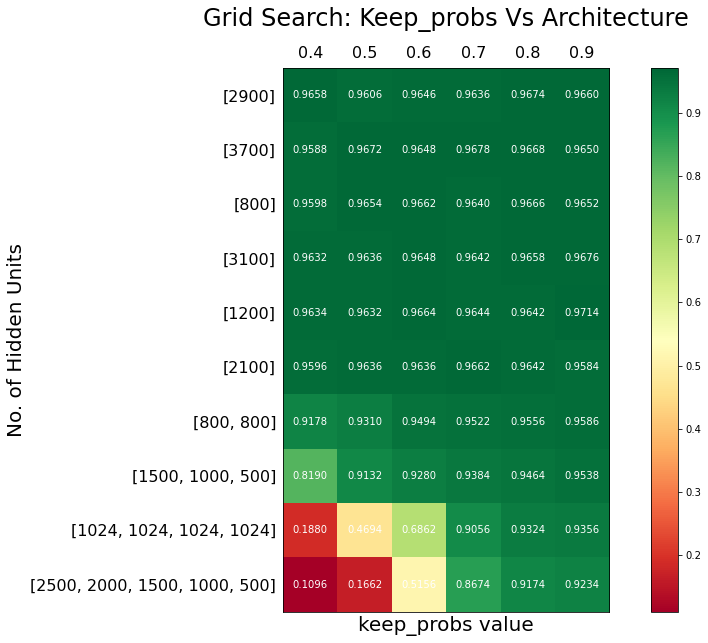

```python
fig, ax = plt.subplots(figsize=(15,10))
im = plt.imshow(score,cmap="RdYlGn") #RdYlGn, PiYG, Accent,Blues,viridis, YlGnBu
fig.colorbar(im,ax=ax,fraction=0.05)

m = len(architecture)
n = len(keep_probs)

ax.set_title("Grid Search: Keep_probs Vs Architecture",fontsize=24,pad = 20)
ax.set_yticks(range(0,m))
ax.set_xticks(range(0,n))
ax.set_ylabel("No. of Hidden Units", fontsize = 20)
ax.set_xlabel("keep_probs value", fontsize = 20)

ax.set_yticklabels(architecture,fontsize=16,rotation=0)
ax.set_xticklabels(keep_probs,fontsize=16)

#setting horizontal axes labeling to top.
ax.xaxis.set_ticks_position('top')
# ax.xaxis.set_label_position('top')


# Turn off all the ticks
ax.tick_params(top=False,left=False)


thres = [0.88, 0.96]

for i in range(m):
    for j in range(n):
        ax.text(j, i, "%.4f"%(score[i, j]),
                       ha="center", va="center", color="w" if score[i,j] < thres[1] or score[i,j] > thres[0]  else "black")


# fig.tight_layout()
plt.show()
```

### Sorted combination of the Search Parameters along with their val accuracy

```python
#generating the combinations of hyperparameters
val_acc = []
probs = []
arch = []
for ind1, i in enumerate(architecture):
        for ind2, j in enumerate(keep_probs):
            val_acc.append(score[ind1,ind2])
            probs.append(j)
            arch.append(i)


top_best = len(val_acc)
#sorting
sorted_score_index = [b[0] for b in sorted(enumerate(val_acc),key=lambda i:i[1], reverse = True)]
val_acc = [np.squeeze(val_acc[i]) for i in sorted_score_index[:top_best]]
probs = [probs[i] for i in sorted_score_index[:top_best]]
arch = [arch[i] for i in sorted_score_index[:top_best]]


print("=========+=================+===============+====================")
print(" S.N\t | Val Accuracy\t | Keep_probs\t | Architecture")
print("=========+=================+===============+====================")
for i in range(top_best):
    print(" %d\t | %.5f\t | %.1f\t\t | %s "%(i+1,val_acc[i], probs[i], str(arch[i])))
```

```
=========+=================+===============+====================
 S.N	 | Val Accuracy	 | Keep_probs	 | Architecture
=========+=================+===============+====================
 1	 | 0.97140	 | 0.9		 | [1200]
 2	 | 0.96780	 | 0.7		 | [3700]
 3	 | 0.96760	 | 0.9		 | [3100]
 4	 | 0.96740	 | 0.8		 | [2900]
 5	 | 0.96720	 | 0.5		 | [3700]
 6	 | 0.96680	 | 0.8		 | [3700]
 7	 | 0.96660	 | 0.8		 | [800]
 8	 | 0.96640	 | 0.6		 | [1200]
 9	 | 0.96620	 | 0.6		 | [800]
 10	 | 0.96620	 | 0.7		 | [2100]
 11	 | 0.96600	 | 0.9		 | [2900]
 12	 | 0.96580	 | 0.4		 | [2900]
 13	 | 0.96580	 | 0.8		 | [3100]
 14	 | 0.96540	 | 0.5		 | [800]
 15	 | 0.96520	 | 0.9		 | [800]
 16	 | 0.96500	 | 0.9		 | [3700]
 17	 | 0.96480	 | 0.6		 | [3700]
 18	 | 0.96480	 | 0.6		 | [3100]
 19	 | 0.96460	 | 0.6		 | [2900]
 20	 | 0.96440	 | 0.7		 | [1200]
 21	 | 0.96420	 | 0.7		 | [3100]
 22	 | 0.96420	 | 0.8		 | [1200]
 23	 | 0.96420	 | 0.8		 | [2100]
 24	 | 0.96400	 | 0.7		 | [800]
 25	 | 0.96360	 | 0.7		 | [2900]
 26	 | 0.96360	 | 0.5		 | [3100]
 27	 | 0.96360	 | 0.5		 | [2100]
 28	 | 0.96360	 | 0.6		 | [2100]
 29	 | 0.96340	 | 0.4		 | [1200]
 30	 | 0.96320	 | 0.4		 | [3100]
 31	 | 0.96320	 | 0.5		 | [1200]
 32	 | 0.96060	 | 0.5		 | [2900]
 33	 | 0.95980	 | 0.4		 | [800]
 34	 | 0.95960	 | 0.4		 | [2100]
 35	 | 0.95880	 | 0.4		 | [3700]
 36	 | 0.95860	 | 0.9		 | [800, 800]
 37	 | 0.95840	 | 0.9		 | [2100]
```

[output cut: 8 more lines]

```
 46	 | 0.93100	 | 0.5		 | [800, 800]
 47	 | 0.92800	 | 0.6		 | [1500, 1000, 500]
 48	 | 0.92340	 | 0.9		 | [2500, 2000, 1500, 1000, 500]
 49	 | 0.91780	 | 0.4		 | [800, 800]
 50	 | 0.91740	 | 0.8		 | [2500, 2000, 1500, 1000, 500]
 51	 | 0.91320	 | 0.5		 | [1500, 1000, 500]
 52	 | 0.90560	 | 0.7		 | [1024, 1024, 1024, 1024]
 53	 | 0.86740	 | 0.7		 | [2500, 2000, 1500, 1000, 500]
 54	 | 0.81900	 | 0.4		 | [1500, 1000, 500]
 55	 | 0.68620	 | 0.6		 | [1024, 1024, 1024, 1024]
 56	 | 0.51560	 | 0.6		 | [2500, 2000, 1500, 1000, 500]
 57	 | 0.46940	 | 0.5		 | [1024, 1024, 1024, 1024]
 58	 | 0.18800	 | 0.4		 | [1024, 1024, 1024, 1024]
 59	 | 0.16620	 | 0.5		 | [2500, 2000, 1500, 1000, 500]
 60	 | 0.10960	 | 0.4		 | [2500, 2000, 1500, 1000, 500]
```

Out of 10 architectures and 6 keep_probs

- 0.9 topped in 6 architectures with 1 being the best of all
- 0.8 topped in 2 architectures
- 0.7 topped in 2 architectures

Best Possible architecture can be:

[output not shown]

Further, tuning of other remaining hyper parameters would be done using this configuration

```python
import os
!jupyter-nbconvert --to html 'Hyper Parameter Tuning - Grid Search .ipynb' --output Experiments/experiment-6/grid_search_architecture_vs_keep_probs_with_complete_search_analysis.html
```

```
[NbConvertApp] Converting notebook Hyper Parameter Tuning - Grid Search .ipynb to html
[NbConvertApp] Writing 464594 bytes to Experiments/experiment-6/grid_search_architecture_vs_keep_probs_with_complete_search_analysis.html
```

Customize the code below to draw parallel coordinate plots of the search results src: https://stackoverflow.com/questions/8230638/parallel-coordinates-plot-in-matplotlib